# Assignment 1 Sotaro Hirai R Notebook

### Prepare packages required for this analysis.

```r
# Load Biobase.
if (! require(Biobase, quietly=TRUE)) {
  if (! exists("biocLite")) {
    source("https://bioconductor.org/biocLite.R")
  }
  biocLite("Biobase")
  library(Biobase)
}
# Load GEOquery.

if (! require(GEOquery, quietly=TRUE)) {
  if (! exists("biocLite")) {
    source("https://bioconductor.org/biocLite.R")
  }
  biocLite("GEOquery")
  library(GEOquery)
}
```

```
## Setting options('download.file.method.GEOquery'='auto')
```

```
## Setting options('GEOquery.inmemory.gpl'=FALSE)
```

```r
library(knitr)
library(edgeR)
```

```r
GSE125150 <- getGEO("GSE125150", GSEMatrix = FALSE)
```

```
## File stored at:
```

```
## /tmp/RtmpCAI8U7/GSE125150.soft.gz
```

```
## Reading file....
```

```
## Parsing....
```

[output not shown]

```
## GPL20301 (1 of 10 entities)
```

```
## GSM3564285 (2 of 10 entities)
```

```
## GSM3564286 (3 of 10 entities)
```

```
## GSM3564287 (4 of 10 entities)
```

```
## GSM3564288 (5 of 10 entities)
```

```
## GSM3564289 (6 of 10 entities)
```

```
## GSM3564290 (7 of 10 entities)
```

```
## GSM3564291 (8 of 10 entities)
```

```
## GSM3564292 (9 of 10 entities)
```

```r
kable(data.frame(head(Meta(GSE125150))), format = "html")
```

| contact_address | contact_city | contact_country | contact_email | contact_institute | contact_laboratory |
| --- | --- | --- | --- | --- | --- |
| 5 Little France Dr | Edinburgh | United Kingdom | s1419027@sms.ed.ac.uk | Centre for Regenerative Medicine | Forrester |

```r
gpl <- names(GPLList(GSE125150))[1]
gpl_info <- Meta(getGEO(gpl))
```

```
## File stored at:
```

```
## /tmp/RtmpCAI8U7/GPL20301.soft
```

**Platform title:** Illumina HiSeq 4000 (Homo sapiens)  
**Submission date:** Jun 09 2015  
**Last update date:** Mar 21 2019  
**Organisms:** Homo sapiens  
**Number of GEO datasets that use this technology:** 2053  
**Number of GEO samples that use this technology:** 46179

### Retrieve supplementary files for the differential expressions.

```r
supp_files <- getGEOSuppFiles("GSE125150")
file_names <- rownames(supp_files)

# Expression data for KLF-1 activated and control samples:
expr <- read.table(file_names[5], header = TRUE, check.names = FALSE, sep = ',')

# Check if properly retrieved:
kable(expr[1:15,1:10], format = "html")
```

|  | gene_id | source | gene_version | gene_name | gene_biotype | phase | K2MT_A | K2MT_B | K2MT_C |
| --- | --- | --- | --- | --- | --- | --- | --- | --- | --- |
| ENSG00000000003 | ENSG00000000003 | ensembl | 14 | TSPAN6 | protein_coding | NA | 557 | 384 | 416 |
| ENSG00000000005 | ENSG00000000005 | ensembl_havana | 5 | TNMD | protein_coding | NA | 0 | 0 | 0 |
| ENSG00000000419 | ENSG00000000419 | ensembl_havana | 12 | DPM1 | protein_coding | NA | 1052 | 1082 | 1093 |
| ENSG00000000457 | ENSG00000000457 | ensembl_havana | 13 | SCYL3 | protein_coding | NA | 483 | 543 | 627 |
| ENSG00000000460 | ENSG00000000460 | havana | 16 | C1orf112 | protein_coding | NA | 278 | 295 | 398 |
| ENSG00000000938 | ENSG00000000938 | ensembl_havana | 12 | FGR | protein_coding | NA | 7019 | 5414 | 5931 |
| ENSG00000000971 | ENSG00000000971 | ensembl_havana | 15 | CFH | protein_coding | NA | 91 | 52 | 243 |
| ENSG00000001036 | ENSG00000001036 | ensembl_havana | 13 | FUCA2 | protein_coding | NA | 5648 | 4683 | 6030 |
| ENSG00000001084 | ENSG00000001084 | havana | 10 | GCLC | protein_coding | NA | 20047 | 18149 | 23182 |
| ENSG00000001167 | ENSG00000001167 | ensembl_havana | 14 | NFYA | protein_coding | NA | 2588 | 2366 | 2766 |
| ENSG00000001460 | ENSG00000001460 | ensembl_havana | 17 | STPG1 | protein_coding | NA | 137 | 76 | 83 |
| ENSG00000001461 | ENSG00000001461 | ensembl_havana | 16 | NIPAL3 | protein_coding | NA | 1025 | 562 | 730 |
| ENSG00000001497 | ENSG00000001497 | ensembl_havana | 16 | LAS1L | protein_coding | NA | 1155 | 974 | 1178 |
| ENSG00000001561 | ENSG00000001561 | ensembl_havana | 6 | ENPP4 | protein_coding | NA | 122 | 97 | 128 |
| ENSG00000001617 | ENSG00000001617 | havana | 11 | SEMA3F | protein_coding | NA | 9 | 4 | 30 |

```r
# Define the groups:
samples <- data.frame(lapply(colnames(expr)[8:15], FUN = function(x){unlist(strsplit(x, split = "_"))[c(2,1)]}))
colnames(samples) <- colnames(expr[8:15])
rownames(samples) <- c("Sample", "Condition")
samples <- data.frame(t(samples))
```

### Clean data if needed.

```r
# Check to see if there are no duplicates:
gene_counts <- sort(table(expr$gene_id), decreasing = TRUE)
gene_counts[gene_counts > 1] # No duplicates
```

```
## named integer(0)
```

The data provided was thorough enough to have HGNC symbols for each gene, so there was no need for identifier mapping.

### Filter any uninformative or weakly expressed data after converting counts to cpm.

```r
# Convert counts to cpm using edgeR:
dim(expr)
```

```
## [1] 60675    15
```

```r
cpms <- cpm(expr[, 8:15])

# Name the rows by their gene names:
rownames(cpms) <- expr[, 5]

# Filter out those that don't have > 1 cpm for at least 4 samples (based on edgeR
# documentation, we want our restrictions to be based on least samples per condition
# we have).
keep <- rowSums(cpms > 1) >= 4
expr_filtered <- expr[keep,]
```

Started with 60675 genes. Filtered down to 13872 genes.

### Plotting the density distribution of my filtered and cpm-converted data.

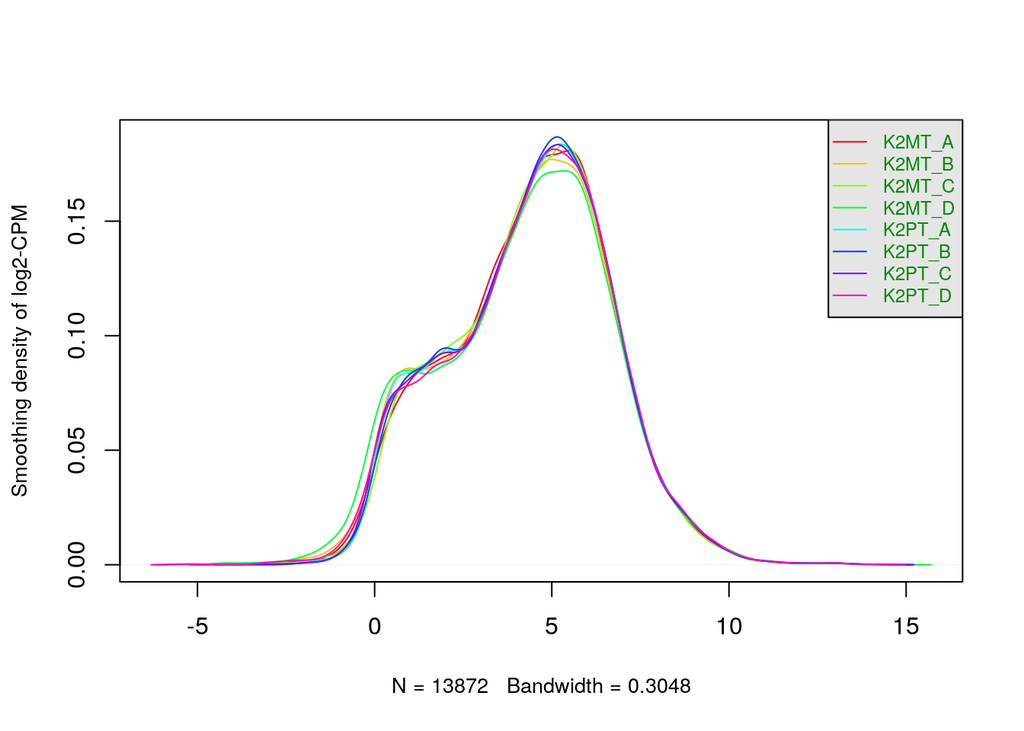

```r
# Make sure to run this chunk as a whole,
# as it leads to an error if run individually.
# Apply log transformation:
cpm_density <- apply(log2(cpm(expr_filtered[, 8:15])), 2, density)

# Calculate the x and y limits of samples:
xlim <- 0
ylim <- 0
for (i in 1:length(cpm_density)) {
  xlim <- range(c(xlim, cpm_density[[i]]$x));
  ylim <- range(c(ylim, cpm_density[[i]]$y))
}

cols <- rainbow(length(cpm_density))
ltys <- rep(1, length(cpm_density))

# Plot density distribution graph (initialize plot):
plot(cpm_density[[1]], xlim = xlim, ylim = ylim, type = "n", ylab = "Smoothing density of log2-CPM", main = "", cex.lab = 0.85)

# Plot lines:
for (i in 1:length(cpm_density)) lines(cpm_density[[i]], col = cols[i], lty = ltys[i])


# Legends:
legend("topright", colnames(expr_filtered[, 8:15]), col = cols, lty = ltys, cex = 0.75, border = "blue", text.col = "green4", merge = TRUE, bg = "gray90")
```

Distribution of our data is roughly normal-distribution, based on a rough estimate from the plot generated above.

Since my data is an RNAseq data and I want to normalize based on samples, I will use Trimmed Means of M-values technique of normalization.

### Plot and compare the distribution between pre- and post-normalization.

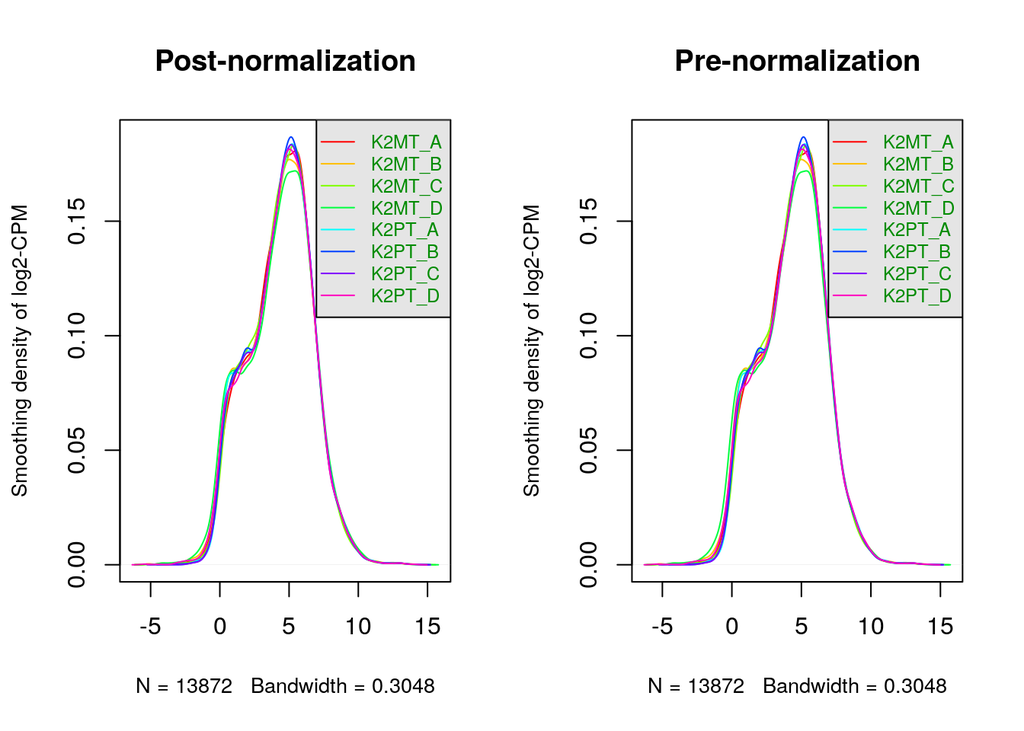

```r
# Convert the filtered data to matrix for TMM:
filtered_data_matrix <- as.matrix(expr_filtered[, 8:15])

# Set the rownames to ensembl ids:
rownames(filtered_data_matrix) <- expr_filtered$gene_id

# Create a DGEList object, based on my data and how I want to compare those (ie. KLF-1+ vs KLF-1-):
d <- DGEList(counts = filtered_data_matrix, group = samples$Condition)

# Calculate normalization factors:
d <- calcNormFactors(d)

# Normalized data:
normalized_counts <- cpm(d)

# Compare plots of pre- vs post-normalization:
normalized_cpm_density <- apply(log2(normalized_counts), 2, density)

# Split the graph window so we can compare the plots:
# Idea based on Holts, Y. (n.d.) Split base R plot window with layout(). Retrieved from:
# https://www.r-graph-gallery.com/75-split-screen-with-layout.html.
layout(matrix(c(1, 2), ncol = 2))

xlim <- 0
ylim <- 0
for (i in 1:length(normalized_cpm_density)) {
  xlim <- range(c(xlim, normalized_cpm_density[[i]]$x));
  ylim <- range(c(ylim, normalized_cpm_density[[i]]$y))
}

cols <- rainbow(length(normalized_cpm_density))
ltys <- rep(1, length(normalized_cpm_density))

# Plot density distribution graph (initialize plot):
plot(normalized_cpm_density[[1]], xlim = xlim, ylim = ylim, type = "n", ylab = "Smoothing density of log2-CPM", main = "Post-normalization", cex.lab = 0.85)

# Plot lines for post-normalization:
for (i in 1:length(normalized_cpm_density)) lines(normalized_cpm_density[[i]], col = cols[i], lty = ltys[i])


# Legends:
legend("topright", colnames(expr_filtered[, 8:15]), col = cols, lty = ltys, cex = 0.75, border = "blue", text.col = "green4", merge = TRUE, bg = "gray90")



# Plot pre-normalization distribution:
xlim <- 0
ylim <- 0
for (i in 1:length(cpm_density)) {
  xlim <- range(c(xlim, cpm_density[[i]]$x));
  ylim <- range(c(ylim, cpm_density[[i]]$y))
}

cols <- rainbow(length(cpm_density))
ltys <- rep(1, length(cpm_density))

# Plot density distribution graph (initialize plot):
plot(cpm_density[[1]], xlim = xlim, ylim = ylim, type = "n", ylab = "Smoothing density of log2-CPM", main = "Pre-normalization", cex.lab = 0.85)

# Plot lines:
for (i in 1:length(cpm_density)) lines(cpm_density[[i]], col = cols[i], lty = ltys[i])


# Legends:
legend("topright", colnames(expr_filtered[, 8:15]), col = cols, lty = ltys, cex = 0.75, border = "blue", text.col = "green4", merge = TRUE, bg = "gray90")
```

The difference between pre- and post-normalization is not apparent, so I will look into common and tag-wise dispersion, as well as MDS.

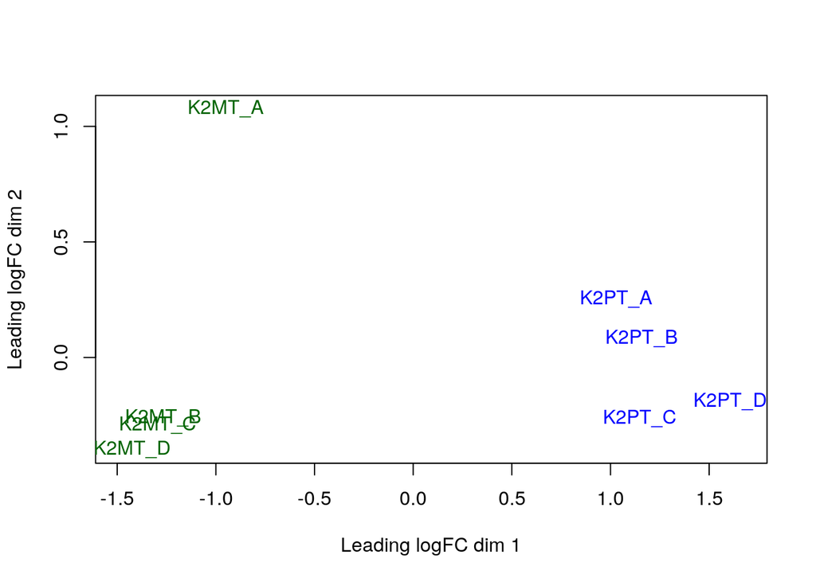

```r
# Plot the MDS for the data after normalization:
plotMDS(d, labels = rownames(samples), col = c("darkgreen", "blue")[factor(samples$Condition)])
```

The data clusters based on the treatment, except for K2MT_A. I could perhaps compare the analysis with and without sample A, to see if this affects the outcome of the analysis, since it looks like an outlier.

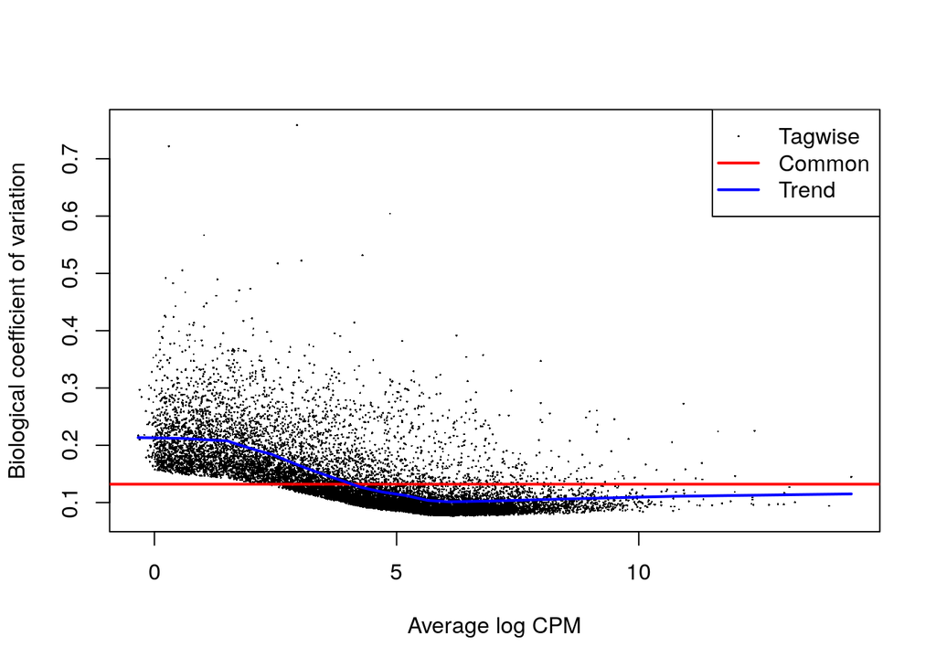

```r
# Estimate dispersion:
model_design <- model.matrix(~samples$Sample + samples$Condition+0)
d <- estimateDisp(d, model_design)
# Plot the graph for BCV:
plotBCV(d, col.tagwise = "black", col.common = "red")
```

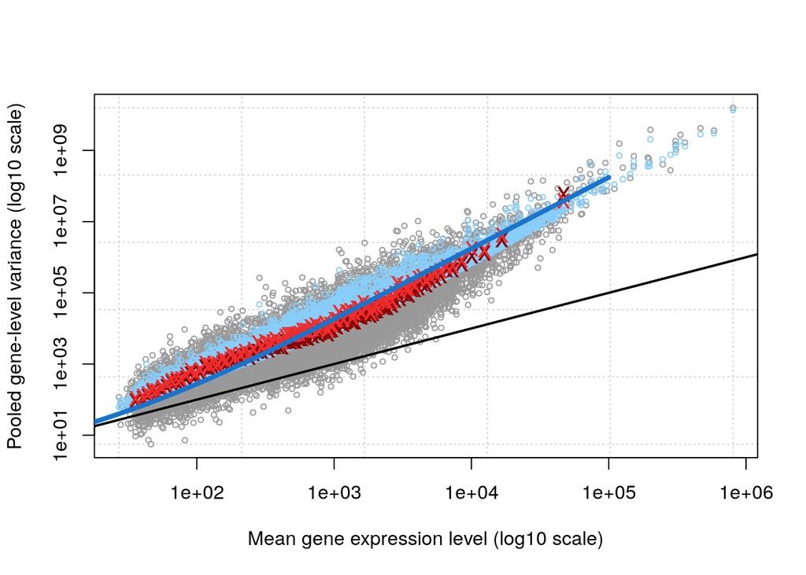

```r
plotMeanVar(d, show.raw.vars = TRUE, show.tagwise.vars = TRUE, NBline = TRUE,
            show.ave.raw.vars = TRUE, show.binned.common.disp.vars = TRUE)
```

Here we see that the influence we get from tagwise vs common dispersion is roughly equivalent as we see many overlaps between the dark and light red points. We also see that both the tagwise and common dispersions roughly follow the negative binomial line in blue, so the assumption of edgeR that the dispersions follow an NB distribution is true. Also, the BCV values from the plot are low, suggesting that the dispersion/variation we see in our samples is low, except for some tagwise dispersions.

### Save the data.

```r
write.table(normalized_counts, "~/GSE125150_normalized_counts.txt", sep = "\t")
```

### Interpretaions

What are the control and test conditions? The control is KLF-1 negative and test is KLF-1 positive samples.

Why is the dataset of interest to you? Because I am interested in immunology and this dataset explores how KLF-1 affects the functioning of macrophages to influence the maturation of erythrocytes.

Were there expression values that were not unique for specific genes? How did you handle these? No, there were no duplicates.

Were there expression values that could not be mapped to current HUGO symbols? No.

How many outliers were removed? 46803 genes were removed after filtering. Sample A looks like an outlier on the MDS plot; however, since it is still positioned in the same area as the other samples of the same condition, I will not consider it an outlier.

How did you handle replicates? All replicate samples were kept.

What is the final coverage of your dataset? The final coverage of my dataset is 13872 starting from 60675.